# Homework 1

Pranav Belligundu - SDS 315 UT Austin

01-23-2025

# **Problem 1:** Beauty, or not, in the classroom

### Part A

Create a histogram to display the overall data distribution of course evaluation scores

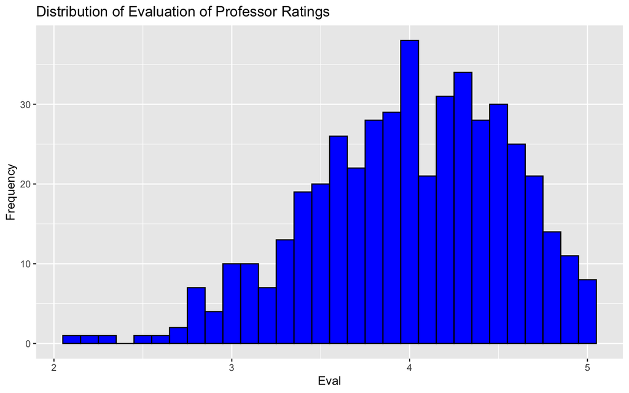

### Part B

Use side-by-side boxplots to show the distribution of course evaluation scores by whether or not the professor is a native English speaker.

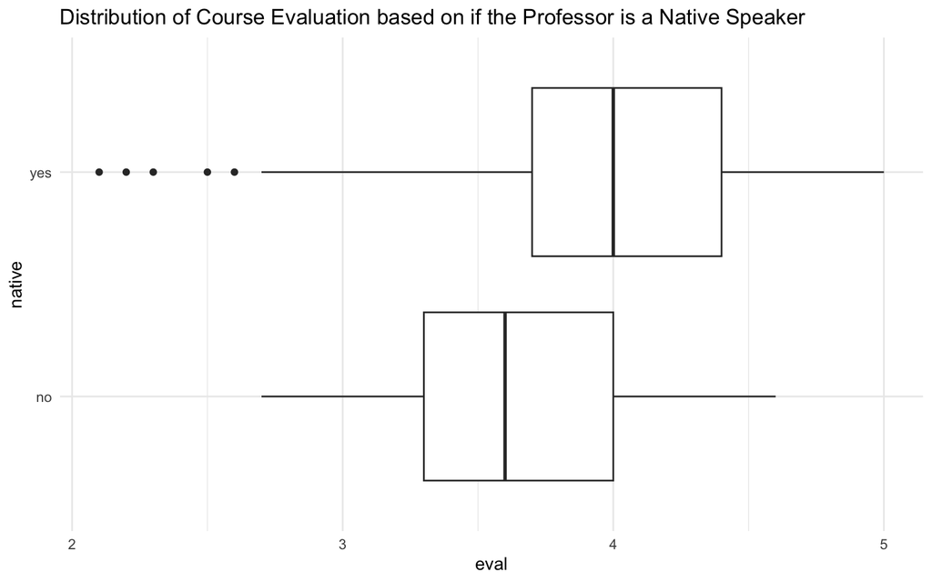

### Part C

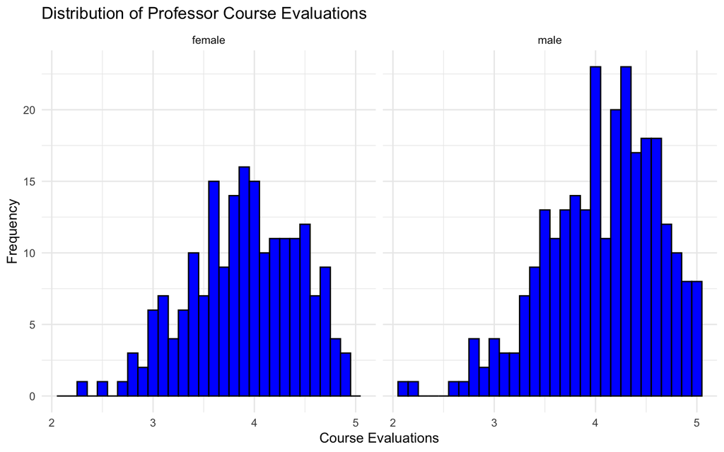

### Part D

Create a scatterplot to visualize the extent to which there may be an association between the professor’s physical attractiveness (x) and their course evaluations (y).

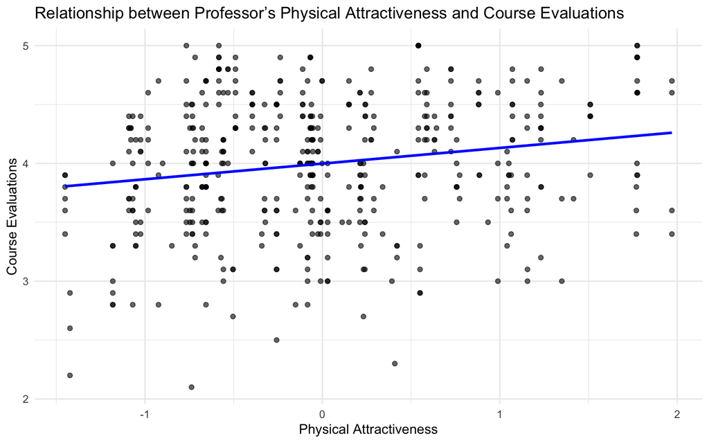

# **Problem 2:** bike sharing

### Plot A

A line graph showing average hourly bike rentals (total) across all hours of the day (hr).

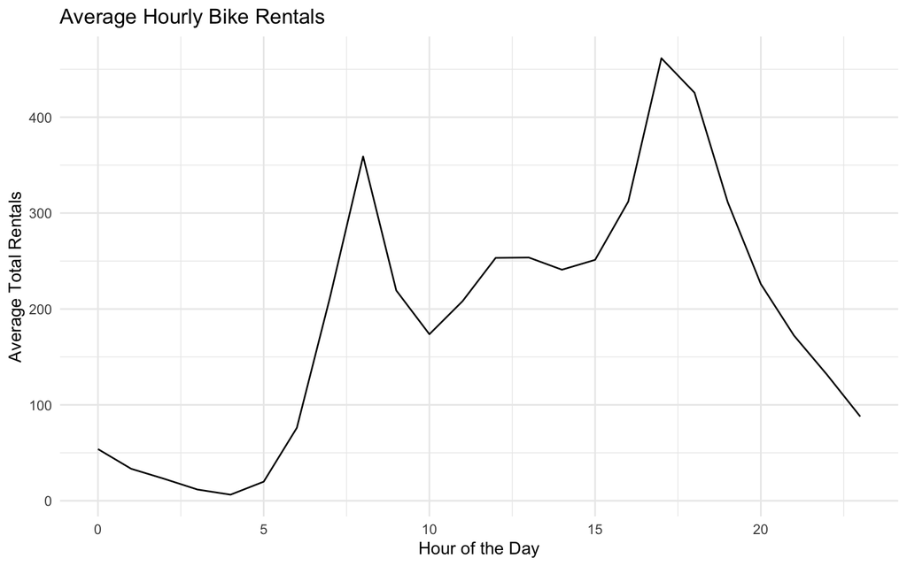

### Plot B

A faceted line graph showing average bike rentals by hour of the day, faceted according to whether it is a working day (workingday).

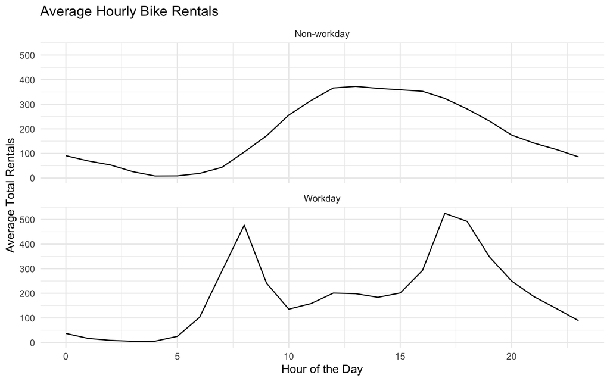

### Plot C

A faceted bar plot showing average ridership (y) during the 9 AM hour by weather situation code (weathersit, x), faceted according to whether it is a working day or not. (Remember that you can focus on a specific subset of rows of a data set using filter.)

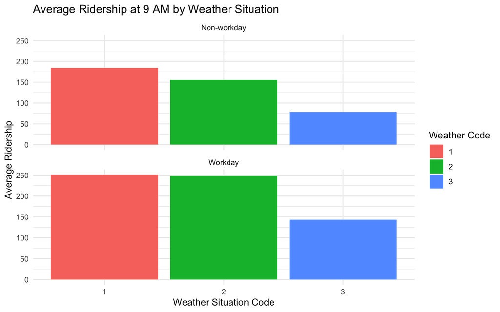

# **Problem 3:** Capital Metro UT Ridership

### Plot 1

One faceted line graph that plots average boardings by hour of the day, day of week, and month. You should facet by day of week. Each facet should include three lines of average boardings (y) by hour of the day (x), one line for each month and distinguished by color

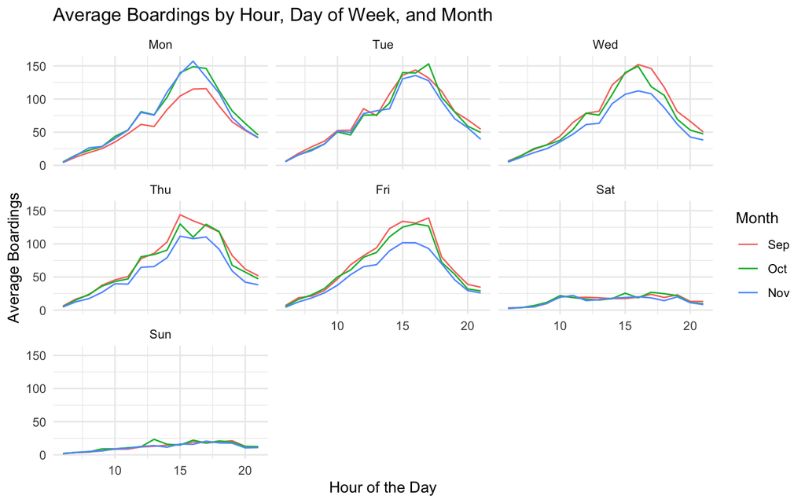

### Plot 2 One faceted scatter plot showing boardings (y) vs. temperature (x), faceted by hour of the day, and with points colored in according to whether it is a weekday or weekend

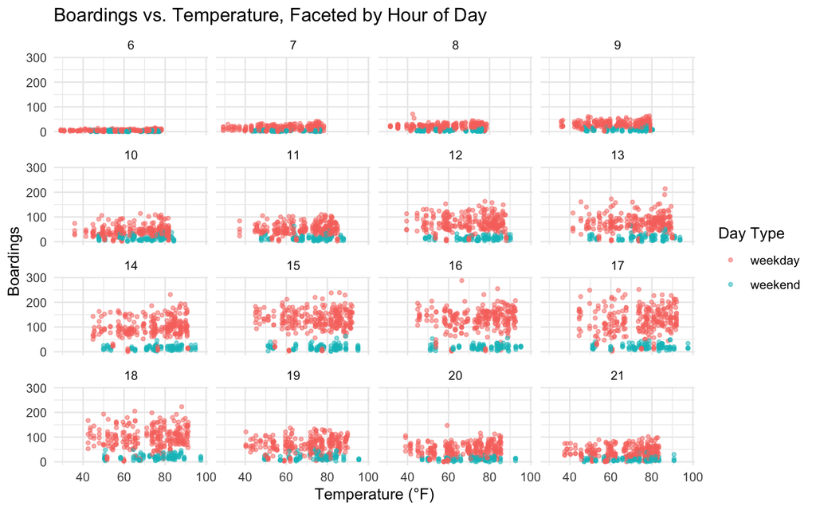

# **Problem 4:** Wrangling the Billboard Top 10

Top 10 Most Popular Songs on Billboard Top 100 Since 1958

| song | performer | total_weeks |
| --- | --- | --- |
| Radioactive | Imagine Dragons | 87 |
| Sail | AWOLNATION | 79 |
| Blinding Lights | The Weeknd | 76 |
| I’m Yours | Jason Mraz | 76 |
| How Do I Live | LeAnn Rimes | 69 |
| Counting Stars | OneRepublic | 68 |
| Party Rock Anthem | LMFAO Featuring Lauren Bennett & GoonRock | 68 |
| Foolish Games/You Were Meant For Me | Jewel | 65 |
| Rolling In The Deep | Adele | 65 |
| Before He Cheats | Carrie Underwood | 64 |